# Checkliste für Kiez-Captains

Haustürwahlkampf Berlin-Mitte

# Vor der Aktion

Um die Koordination vor Ort zu erleichtern erstellt Timur für jede Aktion eine eigene Signal-Gruppe. Bitte prüft am Tag der Aktion ob alle in dieser Liste (https://gruenlink.de/3ogg5fhqpi) angemeldeten Mitglieder in der Gruppe sind und fügt die Personen gegebenenfalls selbst hinzu. Um auf die Tabelle zugreifen zu können, müsst Ihr beim ersten Mal auf “Zugriffsanfrage” klicken.

- ✅ Informationen in Gruppenbeschreibung checken (Treffpunkt, Level, Uhrzeit, Link zur Karte, Link zum Zuhörleitfaden, Link zum Haustür-Tool).
- 💬 Schreibt am Tag der Aktion gegen Mittag die wichtigsten Infos nochmal direkt in die Gruppe.
- 📑 Sind genug Flyer und Postkarten vorhanden? Können sonst in Kreisgeschäftsstelle Mo-Do von 16-18 oder Fr von 15-17 Uhr abgeholt werden. Legt Euch gern einen Vorrat an!

# Vor Ort

1. Sind alle da? Falls jemand zu spät ist: Der Person schonmal schreiben, wo sie dazustoßen kann, und bei Ankunft koordinieren.
2. Haben alle genug Material (Ca. 25-40 QR-Code Postkarten und 40-60 Flyer pro Person)?
3. Teams einteilen (Neueinsteiger*innen mit Erfahrenen, nach Möglichkeit gemischte Teams).
4. Adressen klar zuteilen:
   - Teilt Euch auf die Blockseiten auf (siehe Abbildung 1 und Abbildung 2).
   - Wenn zwei Teams an der gleichen Blockseite unterwegs sind, kommt Euch entgegen und trefft Euch in der Mitte.
   - Lieber etwas mehr Adressen einplanen, damit nicht andauernd neu zugeteilt werden muss.
5. Treffpunkt für nach der Aktion ausmachen [optional unter der Woche].
6. Gemeinsam Türeingabe-Tool starten und richtige Kennung angeben.
7. Wichtige Hinweise (unten) gemeinsam durchgehen.
8. Offene Fragen?
9. Gruppenfoto.
10. Teams losschicken.

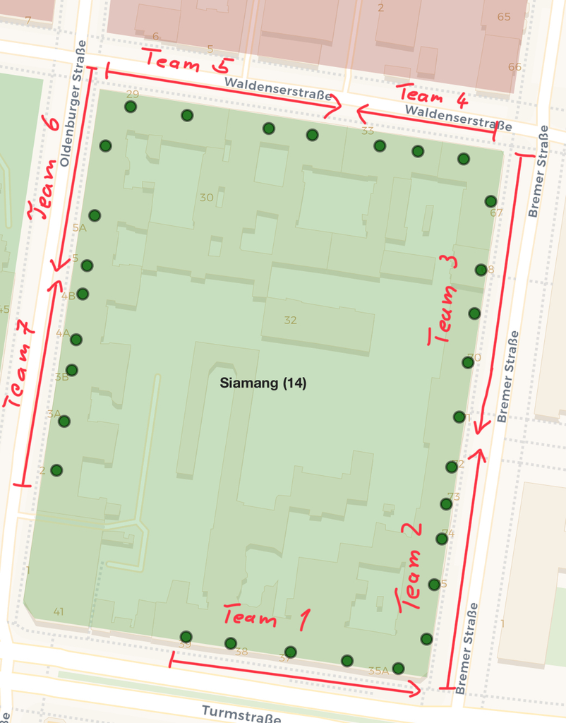

Abbildung 1: Aufteilung bei vielen Teams

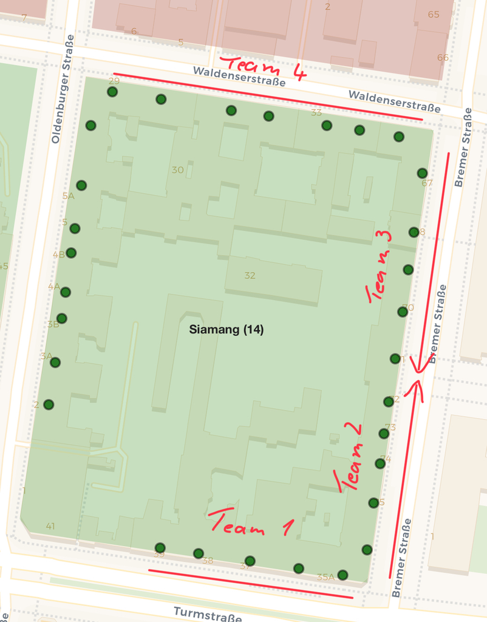

Abbildung 2: Aufteilung bei wenigen Teams

# Wichtige Punkte

[output not shown]

# Unsere Tools

- **Route**: tinyurl.com/wk74maptool
- **Haustür**: tinyurl.com/wk74haustuer
- **Leitfaden**: tinyurl.com/wk74script